# Estils CSS

Estrategia per projectes MUI

Gil Gassó i David García

# La sessió

## Objectiu

Repassar l’estat de l’art en les diferents formes d’aplicar i mantenir estils  
en general, en React i en MUI.

Per pendre una decissió informada sobre  
cap a on anar en els nostres projectes d’UI.

## ⚠️ Disclaimer⚠️

Avancem per terres pantanoses  
No hi ha una solució estable definitiva

Surten frameworks a cada més

MUI mateix canvia cada versió

No hi ha **bala de plata** (encara)

## 🗺️ El camí 🗺️

1. Quins **problemes de gestió d’estils** encarem
2. Repassarem **estratègies** generals existents
3. Acotarem a les solucions que integra **MUI**
4. **Debatrem** quina opció prenem i com **transicionem**
5. Establirem **consensos**

# Els problemes 😈

## 🛑Pareu-nos!🛑

És important tenir un vocabulari comú.

Segurament ja us heu trobats en les situacions que descrivim. No entrarem per no allargar-nos

Pero si no ubiqueu els problemes als que ens referim  
pareu-nos i donarem exemples concrets

Si estàs llegint-ho en diferit,  
alguns exemples en les ‘speaker notes’

## ⚡Forces en Tensió⚡

🎯 Especificitat

🐑 Reusabilitat

🤡 Personalització

## Especificitat 🎯

> Com afinem que una regla afecti a un element?

A un mateix element poden aplicar moltes regles.  
Quines es queden?

S’ordenen per l’especificitat del selector.  
Determinista però complex.

A mesura que afegim regles, creix el perill de que comencin a interferir entre elles.

## 🎯 Estratègies

**Especificitat plana**  
ni selectors alta especificitat, ni combinacions  
Metodologies: BEM, SuitCSS  
Frameworks: Bootstrap, [Mui]

**Jerarquitzar els estils per tipus**  
arquitectures CSS de capes  
Metodologies: ITCSS, SMACSS, Atomic Design

**Acotar l’aplicació de les regles**  
Metodologies: CSS-in-JS, CSS modules…  
Frameworks: Emotion, Styled Components

## Reusabilitat 🐑

> Voldríem no repetir-nos (DRY)

Objectiu: Tenir un sol punt de canvi.

## 🐑 Coses reusables

**Temes**  
uns certs àtoms/tokens que apliquem arreu  
*colors, typografies, mides…*

**Components**  
una estructura html aïllada repetida  
*botons, llistes, barres de navegació…*

**Utilitats:**  
estils que apliquem a elements diversos  
*center, space-evenly, vertical, danger…*

## 🐑 Estrategies

**CSS Preprocessors**  
functions, variables, mixins  
Less, Sass, Stylus

**Components JS**  
Repetim els estils amb el html  
React, Vue…

**Theme system / CSS Variables**

## Personalització 🤡

> Havent generalitzat, com podem diferenciar un cas concret.

Canviar el tema per defecte

Aplicar un tema diferent a certs components

Personalitzar un component

Les altes especificitats compliquen sobreescriure

## 🤡 Solucions

Fer servir especificitat més alta que al component.

Exemples:

Selector combinant la classe original amb la de especilització.

CSS Inline (máxima especificitat)

Sistemes de Temes personalitzables

## Altres consideracions

**Compatibilitat** 🧩  
Res més compatible que CSS pur

**Velocitat** 🚀  
Generar o modificar CSS en el navegador es lent.

**Canvis Dinàmics** ⚙️  
Modificar en execució els attributs CSS.

**Expressivitat** 👄  
Media queries. Dreceres…

## Ens deixem cap?

Si, durant la presentació,  
penseu en cap altra força o criteri,  
afegim-ho per considerar-ho

# Estratègies CSS

## Arquitectures Planes

Exemples: BEM, SuitCSS

Mantenir l’especificitat baixa

```css
.button > .icon  /* La icona dintre d'un boto: MAL! (0,2,0) */
.button-icon` /* La icona del botó: BIEN! (0,1,0) */
/* Independent de la estructura, i, sempre (0,1,0) */

/* Particularització amb modificadors (estat, mode...) */
/* La icona a un boto deshabilitat (0,2,0) */
.button__disabled .button-icon  /* sobrescrivim el general */

/*
Diferents separadors per indicar el tipus
de cada part del nom de la classe:
Block, Element, Modifier
Depén de la metodologia
*/
```

## Jerarquies CSS

Organitzar les regles per especificitat segons la seva natura (a quants elements apliquen)

- **reset** (fuck explorer) -> especificidad tag
- **base** (h1, h2, p, …) -> especificidad tag
- **layout** (stack, vertical, grid…) -> especificidad class (no s’hereten)
- **components** (button…) -> especificidad class
- **state** (disabled, active…) -> especificidad 2 class (customitzat)
- **theme** (dark, ligth, som…) -> variables

## Precompiladors: Sass, Less, Stylus

- DRY: funcions, variables, mixins…
- Aniuament noms (BEM) i selectors (Estructural)
- Ajuden a muntar BEM o jerarquies
- Es com es generen els estils de les llibreries que fem servir

## CSS com a recurs JS

```javascript
import "mystyle.css" // o .styl, .sass, .less
```

Pel fet d’importar-ho, Webpack/Vite  
l’incorporen com a asset compilat, minimitzat…

Per aplicar, afegim les classes al component.

React crea per defecte `index.css` i `App.css`  
Millor eliminar-los i fer servir `CssReset` de Mui.

Dividir per components. Treeshaking pero no aïllem.

## CSS Modules

Resol especificitat i reús a nivell components

```css
// mybutton.module.css
.button { ... } // escrius css pur

// el compilador detecta el .module i genera un css
// afegint una tirallonga única al nom de les classes
.button-tirallonga { ... }
```

```javascript
// Quan l'importes al javascript
import style from "mybutton.module.css"
// retorna un mapa entre les classes originals i les generades
{ button: 'button-tirallonga' }
// i el fem sevir així:
`<Button className={style.button} />`
```

## CSS-in-JS

Codi Javascript que genera CSS

```javascript
// Escrit com a text templatitzat
css = `
button {
  background-color: ${mycolor}
}
`
// Escrit com a objecte javascript
css = {
  button: {
    backgroundColor: mycolor
  }
}
```

## CSS-in-JS

Com ho apliquem als components

**Styled components:** modifica un component existent per generar un segon amb els estils

**Class names:** Com els CSS modules. Cal extreure el css fora.

**Attributes:** `style` (React) o `sx` (MUI)

`style` tradueix directament a l’atribut inline  
`sx` fa tot un seguit de transformacións

## CSS variables

CSS variables: Propietats css especials  
S’hereten i s’apliquen a selectors.  
Es referencien amb la funció `var()`

Brutals per fer theming  
També per evitar magic numbers.  
Tandem amb `calc()/min()/max()/clamp()/...`

Molt suportades pels navegadors  
Ús experimental en theming de MUI 5

# Personalització a MUI

## Variants, atributs…

Components MUI molt estilats per defecte.  
Cada versió canvia el métode per estilar.

Personalització via atributs API:  
`variant`, `dense`, `disableGutters`, `margin`, `color`…

Els components estructurals (`Box`, `Grid`, `Stack`…)  
prenen els atributs html com atributs CSS  
`gap`, `margin`, `justifyItems`…

## [`makeStyles`](https://mui.com/system/styles/basics/)

Deprecat en Mui5! Incompatible React18!

```
import * as React from 'react';
import { makeStyles } from '@mui/styles';
import Button from '@mui/material/Button';

const useStyles = makeStyles({
  mybutton: {
    boxShadow: '0 3px 5px 2px rgba(255, 105, 135, .3)',
    padding: '0 30px',
  },
});

export default function Hook() {
  const classes = useStyles();
  return <Button className={classes.mybutton}>Hook</Button>;
}
```

## `sx` attribute

Segons la documentació,  
la millor manera d’afegir estils als components MUI  
Es pot fer servir a tots els components MUI

En l’exemple següent podem veure com customitzem el component base:

```
<Slider
    defaultValue={30}
    sx={{
        padding: 1, // 1 step d'spacing del tema
        color: 'success.main', // access als colors del tema
    }}
/>
```

## Personalitzar parts del component

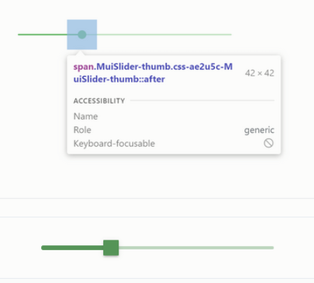

```
<Slider
  defaultValue={30}
  sx={{
    width: 300,
    color: 'success.main',
    '& .MuiSlider-thumb': {
      borderRadius: '1px',
    },
  }}
/>
```

## Sobrescrivint amb className

```css
// PlainCssSlider.css
.slider {
  color: #20b2aa;
}
.slider:hover {
  color: #2e8b57;
}
.slider .MuiSlider-thumb {
  border-radius: 1px;
}
```

```
// PlainCssSlider.jsx
import React from 'react'
import Slider from '@mui/material/Slider'
import 'PlainCssSlider.css'

export default function PlainCssSlider() {
  return  <>
    <Slider defaultValue={30} />
    <Slider
        defaultValue={30}
        className="slider"
    />
  </>
}
```

## Estilant l’estat

Canvis d’estat d’un component:  
`hover`, `focus`, `disabled`…

Problema: L’estat afegeix especificitat  
Cal augmentar la dels descriptors per personalitzar

```
<Button disabled className="Button" />
```

```css
.Button {
  color: black;
}
/* Increase specificity */
.Button:disabled {
  color: white;
}
```

## Estilant l’estat

Problema: Les pseudoclasses només s’apliquen als sub-components nadius.

Per afectar a la resta d’elements dels components, cal fer servir les classes que insereix MUI quan canvia l’estat.

```css
.Button {
  color: black;
}
/* Increase specificity */
.MenuItem.Mui-selected {
  color: blue;
}
```

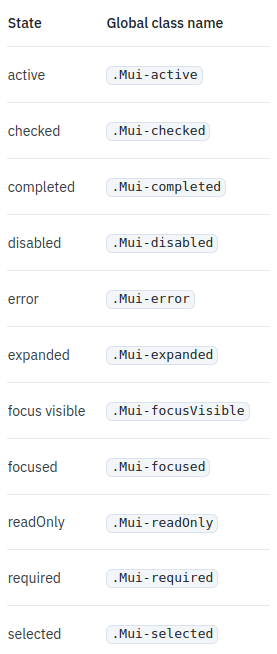

```
<Button disabled className="Button" />
```

## Funció `styled`

```
import * as React from 'react';
import Slider from '@mui/material/Slider';
import { alpha, styled } from '@mui/material/styles';

const SuccessSlider = styled(Slider)(({ theme }) => ({
  width: 300,
  color: theme.palette.success.main,
  '& .MuiSlider-thumb': {
    '&:hover, &.Mui-focusVisible': {
      boxShadow: `0px 0px 0px 8px ' +
        '${alpha(theme.palette.success.main, 0.16)}`,
    },
    '&.Mui-active': {
      boxShadow: `0px 0px 0px 14px ' +
        '${alpha(theme.palette.success.main, 0.16)}`,
    },
  },
}))
```

## Dynamic Overrides

[*Dynamic CSS*](https://mui.com/material-ui/customization/how-to-customize/#dynamic-overrides)

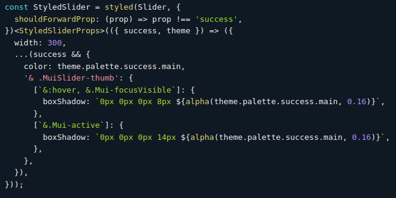

## Dynamic Overrides

[*Variables CSS*](https://mui.com/material-ui/customization/how-to-customize/#dynamic-overrides)

```
const CustomSlider = styled(Slider)({
  width: 300,
  color: 'var(--color, 'black')',
  '& .MuiSlider-thumb': {
    [`&:hover, &.Mui-focusVisible`]: {
      boxShadow: '0px 0px 0px 8px var(--box-shadow, 'grey')',
    },
    [`&.Mui-active`]: {
      boxShadow: '0px 0px 0px 14px var(--box-shadow, 'grey')',
    },
  },
});
```

```
const vars = {
    '--color': '#4caf50'
    '--box-shadow': 'rgb(76, 175, 80, .16)',
}
return <CustomSlider style={vars} />
```

## Global theme overrides

Per alterar l’estil per defecte  
de **totes** les instàncies d’un component  
ho podem fer al tema.

L’atribut `components` del tema  
conté personalitzacions globals per cada component.

Podem canviar atributs per defecte de les propietas del component, o afegir propietats css.

## Global theme overrides

Establim el valor per defecte de la prop  
`disableRipple` del `MuiButtonBase`

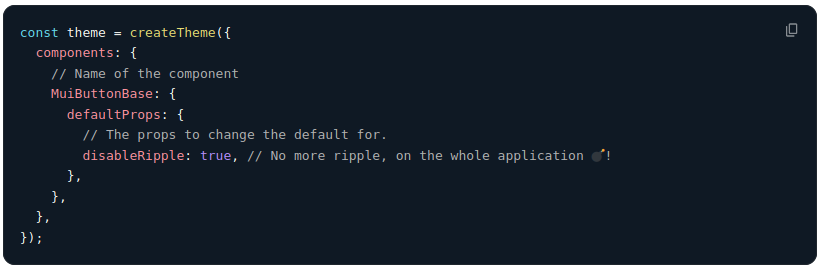

## Global theme overrides

Redefinim els estils del botó. Canviem la mida de la lletra per tots els botons

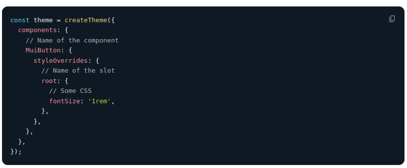

## `CSSBaseline`

`CSSBaseline` proveeix **regles de reset**

Sovint els navegadors tenen diferents estils per defecte.

Les regles de reset aconsegueixen que tots els navegadors parteixin del mateix punt.

```
<>
  <CSSBaseline /> // No es contenidor
  // ...Aqui el component
</>
```

## Global CSS override

Pots fer servir el GlobalStyles per customitzar estils d’alguns dels elements d’html. Per exemple:

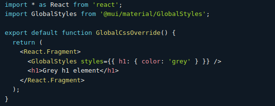

## Global CSS override

Si das servir el GlobalStyles, és millor posar-ho a una constant per no renderitzar cada vegada

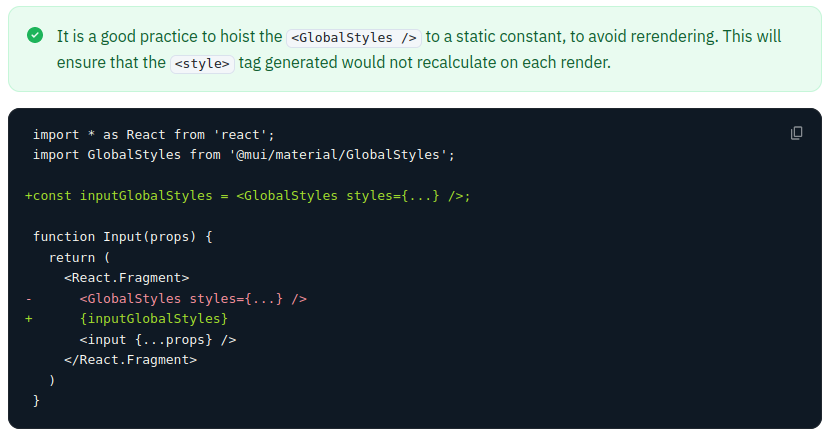

## Global CSS override

Si vols fer servir el CSSBaseline, pots sobreescriure els estils dels components de la següent manera:

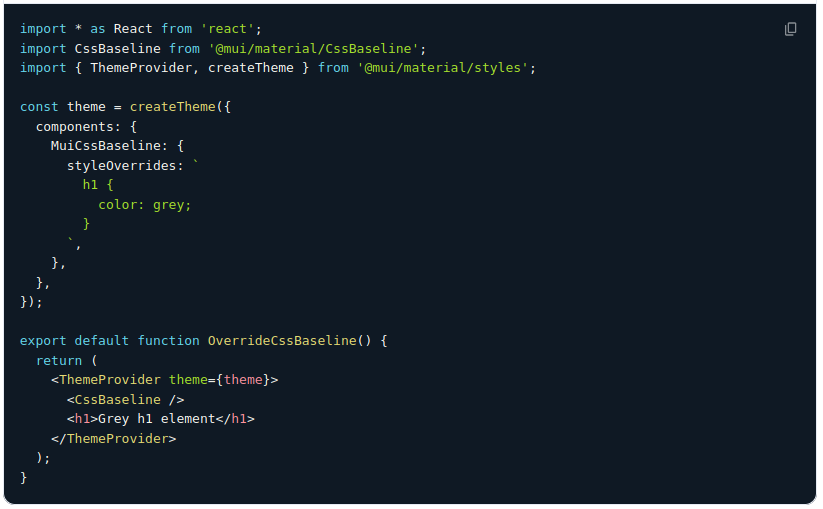

## Migració MUI4 -> MUI5

[*Guia de passar de mui4 a mui5*](https://mui.com/material-ui/migration/migration-v4/)

# Definició i ús de temes

## Accedint al tema

Depenent del tipus d’atribut, alguns components estan disponibles per id:

```
// Podem fer servir el hook, fins i tot a style
const theme = useTheme()
<Box style={{bgcolor: theme.palette.primary.main }} />

// sx ho pot passar via lambda
<Box sx={(theme)=> {bgcolor: theme.palette.primary.main }} />

// Podem posar la lambda al valor
<Box sx={{bgcolor: (theme)=> theme.palette.primary.main }} />

// Recomanat: alguns atributs coneixen els elements del tema per nom
<Box sx={{ bgcolor: `primary.main` }} />
```

## Paleta

El tema conté una paleta amb un conjunt de *colors compostos* redefinibles o *color objects*  
`primary`, `secondary`, `error`, `warning`, `info`, `success`

Compostos perque cadascun té subcomponents o *tokens*:  
`main`, `dark`, `light`, `contrastText`

Podem inventar-nos tant colors (`tertiary`) com a tokens (`superlight`).

## Augmentat de colors

`createTheme` sobrescriu el tema per defecte  
Complementa el que rep

```javascript
createTheme({
  palette: {
    primary: {
      // complementarà dark i contrastText
      main: '#f55',
      light: '#faa',
    },
    // Agafa 'blue' com a main i calcularà la resta
    secondary: 'blue',
    // mantindrà: error, info... del tema per defecte
  }
  // També mantindrà tot el que hi ha fora de palette:
  // breakpoints, typografies...
})
```

## Augmentat de colors

Per augmentar els colors fa servir parametres del `theme.palette`:

`tonalOffset` -> tokens `light` i `dark`  
`contrastThreshold` -> token `contrastText`

Podem personalitzar-los al nostre tema.

**Accessibilitat:** `contrastThreshold` ha de ser mínim 4.5

## Definir custom colors

Per augmentar colors no estàndard,  
cal segona passada per fer servir `augmentColor`  
Necessita un `color.main` i un `name`

```javascript
theme = createTheme(theme, {
  // Custom colors created with augmentColor go here
  palette: {
    tertiary: theme.palette.augmentColor({
      color: {
        main: '#FF5733',
      },
      name: 'tertiary', // Necessari per fer-ho servir per nom
    }),
  },
});
```

## Aplicant paleta

Amb `sx`:  
els posem com string  
agafa tant tokens com colors compostos  
`color: "primary"`  
`color: "error.light"`

Amb `style`:  
cal obtenir el `theme` amb `useTheme`  
cal indicar el token, no el color compost  
`color: theme.palette.primary.main`

## Ús avançat de la paleta

A `sx` podem rebre com a paràmetre el tema  
Aporta funcions per calcular els shades i contrastos

```
<Box sx={({theme})=>({
  color: theme.palette.getContrastText("#443")
})}
```

## Breakpoints al tema

Estableixen tamanys de dispositius per a funcionalitats *responsives*.

```javascript
// Values
theme.breakpoints.keys = ['xs','sm','md','lg','xl']
theme.breakpoints.values = [0, 600, 900, 1200, 1536]
theme.breakpoints.units = 'px'
```

Eines per generar [media-queries](https://developer.mozilla.org/en-US/docs/Web/CSS/@media/width)

```javascript
// functions to return media queries
theme.breakpoints.up(bp) // bp i més grans
theme.breakpoints.down(bp) // bp i més petites
theme.breakpoints.only(bp) // nomes bp
theme.breakpoints.not(bp) // qualsevol menys bp
theme.breakpoints.between(bp1,bp2) // entre b1 i b2 inclosos
```

## Breakpoints a `sx`

```javascript
sx={(theme)=>({
  [theme.breakpoints.up('md')]: {
    display: "none" // oculta per dispositius mitjans
  }
})}
```

Drecera, el nom del breakpoint  
equival a `theme.breakpoint.up(bp)`  
No li cal rebre `theme`

```javascript
// condicionar un conjunt d'atributs
{
  sm: {
    color: "black"
  }
}
```

```javascript
// condicionar els valors d'un atribut
{
  color: {
    sm: "black"
  }
}
```

## Breakpoints amb hooks

Quan volem coneixer el breakpoint fora dels estils.

```javascript
import useMediaQuery from '@mui/material/useMediaQuery'

export default function MyComponent() {
  const isBigEnough = useMediaQuery('(min-width:600px)');

  if (isBigEnough) ...
}
```

## Tipografies

`theme.typography.htmlFontSize`: Font en la que es basa `rem`. No es recomana fixar-la perque l’usuaria la canvia per temes d’accessibilitat.

`theme.typography.fontSize`: El tamany per defecte es 14px. Canvis afectaran proporcionalment.

`theme.typography.fontFamily`: llista separada per comes de noms de fonts.

## Tipografies: variants

`h1`-`h6`, `subtitle1`/`2`, `body1`/`2`, `button`, `caption`, `overline`

`theme.typography.<variant>`: Objecte amb estils per la variant.

## Tipografies: responsives

`fontSize` amb media queries per cada variant

O automàticament a partir de un fontSize:  
[`responsiveFontSizes(theme)`](https://mui.com/material-ui/customization/theming/#responsivefontsizes-theme-options-theme)

## Tipografies: fluïdes

```css
// Fluid font-size: s'adapta de forma continua
// canvia el tamany del bodi
body {
  font-size: calc(
    var(--fluid-font-size-min)
    + (
      var(--fluid-font-size-max) - var(--fluid-font-size-min)
    ) * (
      100vw - var(--fluid-font-min-viewport)
    ) / (
      var(--fluid-font-max-viewport) - var(--fluid-font-min-viewport)
    )
  )
}
```

## Spacing

Defineix espaiats coherents  
`theme.spacing(n)`

Enters a atributs distància d’`sx`

```javascript
<Stack gap={1} /> // 1 = 8px per defecte
```

Personalització

```javascript
createTheme({
  spacing: 4, //  4px
  spacing: (n) => `${0.25 * n}rem`, // Equivalent si 1rem=16px
  spacing: [0,4,8,10,12],
})
```

## zIndex

`theme.zIndex` objecte amb valors de profunditat de referència  
`tooltip > snackbar > modal > drawer > appbar > speeddial > fab > mobilestepper`

## Components temificats

La [Documentació](https://mui.com/material-ui/customization/creating-themed-components/) encara fa servir la funció `styled`.

# Proposta criteris generals

## Resets

Eliminar `App.css` i `index.css` que genera React

Afegir `CssBaseline` a l’arbre de l’aplicació

## Pels atributs de **layout**

El seu significat seria inconexe fora d’una estructura.

Té sentit aplicar-los directament al JSX

Fer servir preferent contenidors estructurals de MUI: Stack, Box, Grid…

Aquest contenidors permeten posar els atributs css com attributs html

## Attributs **look and feel**

Minimitzar customitzacions de components MUI

Si ho fem, fer servir àtoms del tema  
(colors, distancies, tipografies…)

No ens quadren? Afegim un àtom al tema.

Podem calcular shades i contrast colors

Inline? per provar puntualment. Ho movem després.

**Objectius:**  
Mantenir coherència. Single point of change  
Mantenir el tema de forma integrada

## Attributs **look and feel** (2)

Customitzar el tema general hauria de ser una decissió consensuada amb Comunica

Customitzar al tema un component MUI (Button) afecta a tot, si cal fer-ho, de forma quirúrgica i consensuada amb Comunica

Si un tros de l’aplicació funciona amb diferents colors, considerar crear un tema diferent i aplicar un ThemeProvider

## Evitar **paranys**

Canviar sempre color i background a la vegada

Fer servir les funcions del tema  
per calcular colors de contrast i shades

Evitar selectors d’alta especificitat  
`!important`, `#ids`, múltiples classes…

Evitar selectors aniüats  
depenents de l’estructura

# Consensos

## Oficialment

Recollits a aquest [document](https://docs.google.com/document/d/1RXexNAIqNR54ySRsRDJa6Ri36WMQqDa6ueQaZFjJVQw/edit#heading=h.pgagwmctyqs1) (privat)

Pendents de que fan noves versions de MUI

## Quin mecanisme d’estilat?

Fem servir `sx` per MUI (`style` per html pur)

Per contenidors estructurals (layout) prioritzarem  
`Stack`, `Grid`, `Box`  
amb atributs css com si fossin html

```
// Be
<Stack sx={{justifyContent: "space-evenly"}}> ... </Stack>
// Millor
<Stack justifyContent="space-evenly"> ... </Stack>
```

## `styled`?

No hem trobat un cas d’ús  
on `sx` no ho faci més simple que `styled`.

No tanquem la porta a `styled`  
si no es pot fer amb `sx` més simplement.

## Activació del tema

Consensuem concentrar la lógica d’aplicació d’estil a un component contenidor que mourem a la llibreria.

Contrindrà:  
CSS Reset  
Lògica dark theme  
Aplica el ThemeProvider  
**Tema Som per defecte, parametritzable**  
Completesa dels colors del tema  
Càlcul de tipografies responsives  
….

## Personalització de colors

En comptes de posar colors directes `#rrggbb`  
prioritzem fer servir els tokens (colors, tipografies…)  
estàndars del tema (`secondary`, `primary`…)

Varietat amb els subtokens  
`light`, `dark`, `contrastText`…

Si realment necessitem **colors nous**  
definim un nou token al tema  
Nom **funcional**, no descriptiu

## Customitzar components

**Volem canviar l’aspecte d’un component?**

Primer, variants i atributs del component  
`variant`, `color`, `dense`…

No son prou? ⇨ `sx` aplicats localment

Ús repetit? ⇨ nou component que apliqui `sx`  
al component original

Universal i d’acord amb Comunica/UX?  
⇨ `theme.componenents`